# 253-lp-as03

Timothy Paek

2025-03-27

# Preprocessing

The format of the Global Wellbeing Initiative Dataset requires significant preprocessing due to:

Multiple Header Rows: It has rows defining categories, specific questions/responses, and units before the actual data starts.

Hierarchical Structure: The first few columns identify the country and demographic group, while the rest represent survey responses.

Data Type: Values are percentages stored as strings (for example, “48.00%”).

## Preprocessing Global Wellbeing Dataset - Global

```r
# Corrected Column Names for Global Data
# Manually derived by carefully examining the CSV structure (header rows 1, 2, 3)
global_colnames_correct <- c(
  "Demographic_Category", "Demographic_Value",                                      # Cols 1-2
  "Struggling_Index_Pct", "Suffering_Index_Pct", "Thriving_Index_Pct",             # Cols 3-5 (No Yes/No/DK/Ref)
  "Health_Problems_Yes_Pct", "Health_Problems_No_Pct", "Health_Problems_DK_Pct", "Health_Problems_Refused_Pct", # Cols 6-9
  "Count_On_Help_Yes_Pct", "Count_On_Help_No_Pct", "Count_On_Help_DK_Pct", "Count_On_Help_Refused_Pct",       # Cols 10-13
  "Calmness_Yesterday_Yes_Pct", "Calmness_Yesterday_No_Pct", "Calmness_Yesterday_DK_Pct", "Calmness_Yesterday_Refused_Pct", # Cols 14-17
  "Peace_With_Life_Yes_Pct", "Peace_With_Life_No_Pct", "Peace_With_Life_DK_Pct", "Peace_With_Life_Refused_Pct", # Cols 18-21
  "Life_Exciting_Pct", "Life_Calm_Pct", "Life_Both_Pct", "Life_Neither_Pct", "Life_Choice_DK_Pct", "Life_Choice_Refused_Pct", # Cols 22-27
  "Life_Aspects_Balance_Yes_Pct", "Life_Aspects_Balance_No_Pct", "Life_Aspects_Balance_DK_Pct", "Life_Aspects_Balance_Refused_Pct", # Cols 28-31
  "Purpose_Good_At_What_You_Do_Pct", "Purpose_Caring_Family_Friends_Pct", "Purpose_Helping_Others_Pct", "Purpose_None_Pct", "Purpose_Do_Not_Know_Pct", "Purpose_DK_Pct", "Purpose_Refused_Pct", # Cols 32-38
  "Focus_Self_Care_Pct", "Focus_Others_Care_Pct", "Focus_Both_Pct", "Focus_Neither_Pct", "Focus_DK_Pct", "Focus_Refused_Pct", # Cols 39-44
  "Enjoy_Work_Yes_Pct", "Enjoy_Work_No_Pct", "Enjoy_Work_DK_Pct", "Enjoy_Work_Refused_Pct", # Cols 45-48
  "Work_Improves_Others_Lives_Yes_Pct", "Work_Improves_Others_Lives_No_Pct", "Work_Improves_Others_Lives_DK_Pct", "Work_Improves_Others_Lives_Refused_Pct", # Cols 49-52
  "Many_Choices_Work_Yes_Pct", "Many_Choices_Work_No_Pct", "Many_Choices_Work_DK_Pct", "Many_Choices_Work_Refused_Pct" # Cols 53-56
)

# Skip rows 1, 2, 3 (blank, indicator part 1, indicator part 2)
# The 4th row contains "% Response Rate" which I ignore by setting header=FALSE
global_wellbeing_raw <- read_csv("Global Wellbeing Initiative Dataset - Global.csv",
                                 skip = 4, col_names = FALSE, show_col_types = FALSE)

# Check if the number of columns read matches the defined names before assigning
if (ncol(global_wellbeing_raw) != length(global_colnames_correct)) {
  stop(paste("Column count mismatch! Read:", ncol(global_wellbeing_raw),
             "Expected:", length(global_colnames_correct),
             "Check CSV or colnames definition."))
} else {
  # Assign the corrected column names
  colnames(global_wellbeing_raw) <- global_colnames_correct
  print("Column names assigned successfully.")
}
```

```
## [1] "Column names assigned successfully."
```

```r
# Function to clean percentage columns
clean_percentage <- function(x) {
  # Remove '%' sign
  x_cleaned <- str_remove(x, "%")
  # Convert to numeric.
  # Use suppressWarnings to handle NAs from non-numeric values
  x_numeric <- suppressWarnings(as.numeric(x_cleaned))

  x_numeric / 100
}


# Apply cleaning and filtering
global_wellbeing_global_clean <- global_wellbeing_raw %>%
  # Apply cleaning only to columns that should contain percentages (from col 3 onwards)
  mutate(across(3:ncol(.), clean_percentage)) %>%
  # Fill forward the Demographic_Category for rows where it's missing (like age groups)
  fill(Demographic_Category, .direction = "down") %>%
  # Remove rows that might be aggregates or empty (like where Demographic_Value is NA)
  filter(!is.na(Demographic_Value))

# DEBUGGING: Inspect Unique Categories
# Double check that data frame exists and has been processed
if (exists("global_wellbeing_global_clean")) {
  print("Unique values in Demographic_Category after cleaning and filling:")
  unique_categories <- unique(global_wellbeing_global_clean$Demographic_Category)
  print(unique_categories)
} else {
  print("Error: global_wellbeing_global_clean data frame not found. Please run preprocessing code first.")
}
```

```
## [1] "Unique values in Demographic_Category after cleaning and filling:"
## [1] NA                                "Gender"
## [3] "Employment Status"               "Per Capita Income Quintiles"
## [5] "Feelings About Household Income" "Urban/Rural"
```

```r
# Also, look at the first few rows of the *cleaned and filled* data
if (exists("global_wellbeing_global_clean")) {
    print("Head of the cleaned and filled global data:")
    print(head(global_wellbeing_global_clean[, 1:5])) # Show first few columns
}
```

```
## [1] "Head of the cleaned and filled global data:"
## # A tibble: 6 × 5
##   Demographic_Category Demographic_Value Struggling_Index_Pct
##   <chr>                <chr>                            <dbl>
## 1 <NA>                 25-34                            0.512
## 2 <NA>                 35-44                            0.518
## 3 <NA>                 45-64                            0.527
## 4 <NA>                 65+                              0.552
## 5 Gender               Male                             0.527
## 6 Gender               Female                           0.522
## # ℹ 2 more variables: Suffering_Index_Pct <dbl>, Thriving_Index_Pct <dbl>
```

```r
# Display structure and head of the cleaned global data
print("Structure of cleaned global data:")
```

```
## [1] "Structure of cleaned global data:"
```

```r
str(global_wellbeing_global_clean)
```

```
## tibble [25 × 56] (S3: tbl_df/tbl/data.frame)
##  $ Demographic_Category                  : chr [1:25] NA NA NA NA ...
##  $ Demographic_Value                     : chr [1:25] "25-34" "35-44" "45-64" "65+" ...
##  $ Struggling_Index_Pct                  : num [1:25] 0.512 0.518 0.527 0.552 0.527 0.522 0.48 0.559 0.469 0.61 ...
##  $ Suffering_Index_Pct                   : num [1:25] 0.065 0.079 0.102 0.097 0.089 0.069 0.058 0.084 0.052 0.122 ...
##  $ Thriving_Index_Pct                    : num [1:25] 0.423 0.403 0.371 0.351 0.383 0.408 0.462 0.356 0.479 0.267 ...
##  $ Health_Problems_Yes_Pct               : num [1:25] 0.107 0.153 0.274 0.398 0.177 0.236 0.117 0.164 0.193 0.187 ...
##  $ Health_Problems_No_Pct                : num [1:25] 0.892 0.846 0.721 0.596 0.82 0.761 0.881 0.832 0.802 0.812 ...
##  $ Health_Problems_DK_Pct                : num [1:25] 0.001 0.001 0.004 0.006 0.003 0.003 0.002 0.003 0.003 0.001 ...
##  $ Health_Problems_Refused_Pct           : num [1:25] 0 0 0 0.001 0 0 0 0 0.001 0 ...
##  $ Count_On_Help_Yes_Pct                 : num [1:25] 0.861 0.841 0.834 0.876 0.849 0.871 0.89 0.828 0.916 0.757 ...
##  $ Count_On_Help_No_Pct                  : num [1:25] 0.134 0.15 0.155 0.119 0.142 0.123 0.102 0.164 0.079 0.235 ...
##  $ Count_On_Help_DK_Pct                  : num [1:25] 0.005 0.008 0.01 0.006 0.009 0.006 0.008 0.008 0.005 0.008 ...
##  $ Count_On_Help_Refused_Pct             : num [1:25] 0 0 0 0 0 0 0 0 0 0 ...
##  $ Calmness_Yesterday_Yes_Pct            : num [1:25] 0.741 0.743 0.785 0.834 0.783 0.76 0.774 0.756 0.796 0.697 ...
```

[output cut: 42 more lines]

```r
print("Head of cleaned global data:")
```

```
## [1] "Head of cleaned global data:"
```

```r
head(global_wellbeing_global_clean)
```

```
## # A tibble: 6 × 56
##   Demographic_Category Demographic_Value Struggling_Index_Pct
##   <chr>                <chr>                            <dbl>
## 1 <NA>                 25-34                            0.512
## 2 <NA>                 35-44                            0.518
## 3 <NA>                 45-64                            0.527
## 4 <NA>                 65+                              0.552
## 5 Gender               Male                             0.527
## 6 Gender               Female                           0.522
## # ℹ 53 more variables: Suffering_Index_Pct <dbl>, Thriving_Index_Pct <dbl>,
## #   Health_Problems_Yes_Pct <dbl>, Health_Problems_No_Pct <dbl>,
## #   Health_Problems_DK_Pct <dbl>, Health_Problems_Refused_Pct <dbl>,
## #   Count_On_Help_Yes_Pct <dbl>, Count_On_Help_No_Pct <dbl>,
## #   Count_On_Help_DK_Pct <dbl>, Count_On_Help_Refused_Pct <dbl>,
## #   Calmness_Yesterday_Yes_Pct <dbl>, Calmness_Yesterday_No_Pct <dbl>,
## #   Calmness_Yesterday_DK_Pct <dbl>, Calmness_Yesterday_Refused_Pct <dbl>, …
```

```r
# Check for NAs introduced during conversion - indicates potential non-percentage values
na_summary <- sapply(global_wellbeing_global_clean[, 3:ncol(global_wellbeing_global_clean)], function(x) sum(is.na(x)))
print("NA counts per percentage column after cleaning:")
```

```
## [1] "NA counts per percentage column after cleaning:"
```

```r
print(na_summary[na_summary > 0]) # Print only columns with NAs
```

```
## named integer(0)
```

## Processing Global Wellbeing Dataset - Country Level

Preprocessing the Country Level Dataset similar to the Global level dataset.

```r
# Preprocessing: Country Level Dataset (Revised)

# Use the corrected column names vector for country data
country_colnames_correct <- c(
  "Country", "Demographic_Category", "Demographic_Value",
  "Struggling_Index_Pct", "Suffering_Index_Pct", "Thriving_Index_Pct",
  "Health_Problems_Yes_Pct", "Health_Problems_No_Pct", "Health_Problems_DK_Pct", "Health_Problems_Refused_Pct",
  "Count_On_Help_Yes_Pct", "Count_On_Help_No_Pct", "Count_On_Help_DK_Pct", "Count_On_Help_Refused_Pct",
  "Calmness_Yesterday_Yes_Pct", "Calmness_Yesterday_No_Pct", "Calmness_Yesterday_DK_Pct", "Calmness_Yesterday_Refused_Pct",
  "Peace_With_Life_Yes_Pct", "Peace_With_Life_No_Pct", "Peace_With_Life_DK_Pct", "Peace_With_Life_Refused_Pct",
  "Life_Exciting_Pct", "Life_Calm_Pct", "Life_Both_Pct", "Life_Neither_Pct", "Life_Choice_DK_Pct", "Life_Choice_Refused_Pct",
  "Life_Aspects_Balance_Yes_Pct", "Life_Aspects_Balance_No_Pct", "Life_Aspects_Balance_DK_Pct", "Life_Aspects_Balance_Refused_Pct",
  "Purpose_Good_At_What_You_Do_Pct", "Purpose_Caring_Family_Friends_Pct", "Purpose_Helping_Others_Pct", "Purpose_None_Pct", "Purpose_Do_Not_Know_Pct", "Purpose_DK_Pct", "Purpose_Refused_Pct",
  "Focus_Self_Care_Pct", "Focus_Others_Care_Pct", "Focus_Both_Pct", "Focus_Neither_Pct", "Focus_DK_Pct", "Focus_Refused_Pct",
  "Enjoy_Work_Yes_Pct", "Enjoy_Work_No_Pct", "Enjoy_Work_DK_Pct", "Enjoy_Work_Refused_Pct",
  "Work_Improves_Others_Lives_Yes_Pct", "Work_Improves_Others_Lives_No_Pct", "Work_Improves_Others_Lives_DK_Pct", "Work_Improves_Others_Lives_Refused_Pct",
  "Many_Choices_Work_Yes_Pct", "Many_Choices_Work_No_Pct", "Many_Choices_Work_DK_Pct", "Many_Choices_Work_Refused_Pct"
)

# Skip rows 1, 2, 3 (blank, indicator part 1, indicator part 2)
# The 4th row contains "% Response Rate" which I ignore by setting header=FALSE
country_wellbeing_raw <- read_csv("Global Wellbeing Initiative Dataset - Country Level.csv",
                                  skip = 4, col_names = FALSE, show_col_types = FALSE)

# Check if the number of columns read matches the defined names BEFORE assigning
if (ncol(country_wellbeing_raw) != length(country_colnames_correct)) {
  stop(paste("Column count mismatch! Read:", ncol(country_wellbeing_raw),
             "Expected:", length(country_colnames_correct),
             "Check CSV or country_colnames_correct definition."))
} else {
  # Assign the corrected column names
  colnames(country_wellbeing_raw) <- country_colnames_correct
  print("Country column names assigned successfully.")
}
```

```
## [1] "Country column names assigned successfully."
```

```r
# Use the same cleaning function as before
clean_percentage <- function(x) {
  x_cleaned <- str_remove(x, "%")
  x_numeric <- suppressWarnings(as.numeric(x_cleaned))
  x_numeric / 100
}

# Apply cleaning and filtering to the country data
country_wellbeing_clean <- country_wellbeing_raw %>%
  # Apply cleaning only to columns that should contain percentages (from col 4 onwards)
  mutate(across(4:ncol(.), clean_percentage)) %>%
  # Deal with missing rows
  fill(Country, .direction = "down") %>%
  fill(Demographic_Category, .direction = "down") %>%
  # Remove na rows
  filter(!is.na(Demographic_Value))

# Display structure and head of the cleaned country data
print("Structure of cleaned country data:")
```

```
## [1] "Structure of cleaned country data:"
```

```r
str(country_wellbeing_clean)
```

```
## tibble [1,325 × 57] (S3: tbl_df/tbl/data.frame)
##  $ Country                               : chr [1:1325] NA NA NA NA ...
##  $ Demographic_Category                  : chr [1:1325] NA NA NA NA ...
##  $ Demographic_Value                     : chr [1:1325] "25-34" "35-44" "45-64" "65+" ...
##  $ Struggling_Index_Pct                  : num [1:1325] 0.342 0.403 0.411 0.43 0.417 0.408 0.352 0.376 0.388 0.459 ...
##  $ Suffering_Index_Pct                   : num [1:1325] 0.017 0.032 0.031 0.023 0.029 0.032 0.016 0.018 0 0.115 ...
##  $ Thriving_Index_Pct                    : num [1:1325] 0.641 0.565 0.558 0.547 0.555 0.56 0.632 0.606 0.612 0.426 ...
##  $ Health_Problems_Yes_Pct               : num [1:1325] 0.133 0.122 0.218 0.238 0.154 0.197 0.09 0.151 0.161 0.193 ...
##  $ Health_Problems_No_Pct                : num [1:1325] 0.867 0.878 0.782 0.756 0.846 0.801 0.91 0.849 0.839 0.807 ...
##  $ Health_Problems_DK_Pct                : num [1:1325] 0 0 0 0.002 0 0.001 0 0 0 0 ...
##  $ Health_Problems_Refused_Pct           : num [1:1325] 0 0 0 0.005 0 0.002 0 0 0 0 ...
##  $ Count_On_Help_Yes_Pct                 : num [1:1325] 0.896 0.819 0.966 0.969 0.928 0.943 0.947 0.961 0.975 0.743 ...
##  $ Count_On_Help_No_Pct                  : num [1:1325] 0.104 0.181 0.034 0.02 0.068 0.057 0.053 0.039 0.025 0.257 ...
##  $ Count_On_Help_DK_Pct                  : num [1:1325] 0 0 0 0.011 0.004 0 0 0 0 0 ...
##  $ Count_On_Help_Refused_Pct             : num [1:1325] 0 0 0 0 0 0 0 0 0 0 ...
```

[output cut: 43 more lines]

```r
print("Head of cleaned country data:")
```

```
## [1] "Head of cleaned country data:"
```

```r
head(country_wellbeing_clean)
```

```
## # A tibble: 6 × 57
##   Country Demographic_Category Demographic_Value Struggling_Index_Pct
##   <chr>   <chr>                <chr>                            <dbl>
## 1 <NA>    <NA>                 25-34                            0.342
## 2 <NA>    <NA>                 35-44                            0.403
## 3 <NA>    <NA>                 45-64                            0.411
## 4 <NA>    <NA>                 65+                              0.43
## 5 <NA>    Gender               Male                             0.417
## 6 <NA>    Gender               Female                           0.408
## # ℹ 53 more variables: Suffering_Index_Pct <dbl>, Thriving_Index_Pct <dbl>,
## #   Health_Problems_Yes_Pct <dbl>, Health_Problems_No_Pct <dbl>,
## #   Health_Problems_DK_Pct <dbl>, Health_Problems_Refused_Pct <dbl>,
## #   Count_On_Help_Yes_Pct <dbl>, Count_On_Help_No_Pct <dbl>,
## #   Count_On_Help_DK_Pct <dbl>, Count_On_Help_Refused_Pct <dbl>,
## #   Calmness_Yesterday_Yes_Pct <dbl>, Calmness_Yesterday_No_Pct <dbl>,
## #   Calmness_Yesterday_DK_Pct <dbl>, Calmness_Yesterday_Refused_Pct <dbl>, …
```

```r
# Check for NAs introduced during conversion
na_summary_country <- sapply(country_wellbeing_clean[, 4:ncol(country_wellbeing_clean)], function(x) sum(is.na(x)))
print("NA counts per percentage column after country cleaning:")
```

```
## [1] "NA counts per percentage column after country cleaning:"
```

```r
print(na_summary_country[na_summary_country > 0]) # Print only columns with NAs
```

```
## named integer(0)
```

```r
# Make Aggregated Country Dataset
# This uses the now correctly preprocessed 'country_wellbeing_clean'
# I still use the 'Gender'='Male' proxy for this example
country_wellbeing_aggregated <- country_wellbeing_clean %>%
  filter(Demographic_Category == "Gender", Demographic_Value == "Male") %>%
  select(-Demographic_Category, -Demographic_Value) # Remove redundant columns

print("Structure of re-created aggregated country data (using Gender=Male as proxy):")
```

```
## [1] "Structure of re-created aggregated country data (using Gender=Male as proxy):"
```

```r
str(country_wellbeing_aggregated)
```

```
## tibble [51 × 55] (S3: tbl_df/tbl/data.frame)
##  $ Country                               : chr [1:51] NA "Egypt" "Morocco" "Saudi Arabia" ...
##  $ Struggling_Index_Pct                  : num [1:51] 0.417 0.588 0.639 0.561 0.519 0.379 0.625 0.379 0.281 0.494 ...
##  $ Suffering_Index_Pct                   : num [1:51] 0.029 0.246 0.129 0.035 0.319 0.064 0.038 0.013 0.001 0.05 ...
##  $ Thriving_Index_Pct                    : num [1:51] 0.555 0.165 0.232 0.405 0.162 0.557 0.336 0.607 0.718 0.456 ...
##  $ Health_Problems_Yes_Pct               : num [1:51] 0.154 0.187 0.197 0.104 0.116 0.183 0.166 0.219 0.174 0.188 ...
##  $ Health_Problems_No_Pct                : num [1:51] 0.846 0.813 0.802 0.894 0.884 0.817 0.834 0.781 0.822 0.809 ...
##  $ Health_Problems_DK_Pct                : num [1:51] 0 0 0.001 0.002 0 0 0 0 0.005 0.003 ...
##  $ Health_Problems_Refused_Pct           : num [1:51] 0 0 0 0 0 0 0 0 0 0 ...
##  $ Count_On_Help_Yes_Pct                 : num [1:51] 0.928 0.647 0.451 0.878 0.817 0.892 0.923 0.907 0.958 0.922 ...
##  $ Count_On_Help_No_Pct                  : num [1:51] 0.068 0.345 0.529 0.121 0.162 0.102 0.077 0.091 0.036 0.071 ...
##  $ Count_On_Help_DK_Pct                  : num [1:51] 0.004 0.008 0.02 0 0.02 0.007 0 0.002 0.006 0.008 ...
##  $ Count_On_Help_Refused_Pct             : num [1:51] 0 0 0 0.001 0.001 0 0 0 0 0 ...
##  $ Calmness_Yesterday_Yes_Pct            : num [1:51] 0.839 0.732 0.764 0.768 0.705 0.667 0.739 0.795 0.868 0.627 ...
##  $ Calmness_Yesterday_No_Pct             : num [1:51] 0.157 0.261 0.205 0.232 0.266 0.325 0.26 0.193 0.132 0.368 ...
```

[output cut: 41 more lines]

```r
print("Head of re-created aggregated country data:")
```

```
## [1] "Head of re-created aggregated country data:"
```

```r
head(country_wellbeing_aggregated)
```

```
## # A tibble: 6 × 55
##   Country        Struggling_Index_Pct Suffering_Index_Pct Thriving_Index_Pct
##   <chr>                         <dbl>               <dbl>              <dbl>
## 1 <NA>                          0.417               0.029              0.555
## 2 Egypt                         0.588               0.246              0.165
## 3 Morocco                       0.639               0.129              0.232
## 4 Saudi Arabia                  0.561               0.035              0.405
## 5 Turkey                        0.519               0.319              0.162
## 6 United Kingdom                0.379               0.064              0.557
## # ℹ 51 more variables: Health_Problems_Yes_Pct <dbl>,
## #   Health_Problems_No_Pct <dbl>, Health_Problems_DK_Pct <dbl>,
## #   Health_Problems_Refused_Pct <dbl>, Count_On_Help_Yes_Pct <dbl>,
## #   Count_On_Help_No_Pct <dbl>, Count_On_Help_DK_Pct <dbl>,
## #   Count_On_Help_Refused_Pct <dbl>, Calmness_Yesterday_Yes_Pct <dbl>,
## #   Calmness_Yesterday_No_Pct <dbl>, Calmness_Yesterday_DK_Pct <dbl>,
## #   Calmness_Yesterday_Refused_Pct <dbl>, Peace_With_Life_Yes_Pct <dbl>, …
```

## Preprocessing World Happiness Report

This one is much more straightforward.

```r
# Preprocessing: World Happiness Report 2019 (Corrected Rename)

# Read CSV
whr_2019_raw <- read_csv("world_happiness_report/2019.csv", show_col_types = FALSE)

# Clean column names (convert to snake_case)
whr_2019_clean <- whr_2019_raw %>%
  clean_names() %>%
  # Rename TO 'Country' (Uppercase C) to match the GWBI dataset column name (to later combine datasets)
  rename(Country = country_or_region)

# Look at structure and data types
print("Structure of cleaned WHR 2019 data (Corrected Rename):")
```

```
## [1] "Structure of cleaned WHR 2019 data (Corrected Rename):"
```

```r
str(whr_2019_clean)
```

```
## spc_tbl_ [156 × 9] (S3: spec_tbl_df/tbl_df/tbl/data.frame)
##  $ overall_rank                : num [1:156] 1 2 3 4 5 6 7 8 9 10 ...
##  $ Country                     : chr [1:156] "Finland" "Denmark" "Norway" "Iceland" ...
##  $ score                       : num [1:156] 7.77 7.6 7.55 7.49 7.49 ...
##  $ gdp_per_capita              : num [1:156] 1.34 1.38 1.49 1.38 1.4 ...
##  $ social_support              : num [1:156] 1.59 1.57 1.58 1.62 1.52 ...
##  $ healthy_life_expectancy     : num [1:156] 0.986 0.996 1.028 1.026 0.999 ...
##  $ freedom_to_make_life_choices: num [1:156] 0.596 0.592 0.603 0.591 0.557 0.572 0.574 0.585 0.584 0.532 ...
##  $ generosity                  : num [1:156] 0.153 0.252 0.271 0.354 0.322 0.263 0.267 0.33 0.285 0.244 ...
##  $ perceptions_of_corruption   : num [1:156] 0.393 0.41 0.341 0.118 0.298 0.343 0.373 0.38 0.308 0.226 ...
##  - attr(*, "spec")=
##   .. cols(
##   ..   `Overall rank` = col_double(),
##   ..   `Country or region` = col_character(),
##   ..   Score = col_double(),
##   ..   `GDP per capita` = col_double(),
##   ..   `Social support` = col_double(),
##   ..   `Healthy life expectancy` = col_double(),
##   ..   `Freedom to make life choices` = col_double(),
##   ..   Generosity = col_double(),
##   ..   `Perceptions of corruption` = col_double()
##   .. )
##  - attr(*, "problems")=<externalptr>
```

```r
# Check the first few rows
print("Head of cleaned WHR 2019 data (Corrected Rename):")
```

```
## [1] "Head of cleaned WHR 2019 data (Corrected Rename):"
```

```r
head(whr_2019_clean)
```

```
## # A tibble: 6 × 9
##   overall_rank Country     score gdp_per_capita social_support
##          <dbl> <chr>       <dbl>          <dbl>          <dbl>
## 1            1 Finland      7.77           1.34           1.59
## 2            2 Denmark      7.6            1.38           1.57
## 3            3 Norway       7.55           1.49           1.58
## 4            4 Iceland      7.49           1.38           1.62
## 5            5 Netherlands  7.49           1.40           1.52
## 6            6 Switzerland  7.48           1.45           1.53
## # ℹ 4 more variables: healthy_life_expectancy <dbl>,
## #   freedom_to_make_life_choices <dbl>, generosity <dbl>,
## #   perceptions_of_corruption <dbl>
```

```r
# Check summary statistics for potential issues
print("Summary of cleaned WHR 2019 data (Corrected Rename):")
```

```
## [1] "Summary of cleaned WHR 2019 data (Corrected Rename):"
```

```r
summary(whr_2019_clean)
```

```
##   overall_rank      Country              score       gdp_per_capita
##  Min.   :  1.00   Length:156         Min.   :2.853   Min.   :0.0000
##  1st Qu.: 39.75   Class :character   1st Qu.:4.545   1st Qu.:0.6027
##  Median : 78.50   Mode  :character   Median :5.380   Median :0.9600
##  Mean   : 78.50                      Mean   :5.407   Mean   :0.9051
##  3rd Qu.:117.25                      3rd Qu.:6.184   3rd Qu.:1.2325
##  Max.   :156.00                      Max.   :7.769   Max.   :1.6840
##  social_support  healthy_life_expectancy freedom_to_make_life_choices
##  Min.   :0.000   Min.   :0.0000          Min.   :0.0000
##  1st Qu.:1.056   1st Qu.:0.5477          1st Qu.:0.3080
##  Median :1.272   Median :0.7890          Median :0.4170
##  Mean   :1.209   Mean   :0.7252          Mean   :0.3926
##  3rd Qu.:1.452   3rd Qu.:0.8818          3rd Qu.:0.5072
##  Max.   :1.624   Max.   :1.1410          Max.   :0.6310
##    generosity     perceptions_of_corruption
##  Min.   :0.0000   Min.   :0.0000
##  1st Qu.:0.1087   1st Qu.:0.0470
##  Median :0.1775   Median :0.0855
##  Mean   :0.1848   Mean   :0.1106
##  3rd Qu.:0.2482   3rd Qu.:0.1412
##  Max.   :0.5660   Max.   :0.4530
```

## Data Integration

```r
# Data Integration
# Ensure both dataframes ('country_wellbeing_aggregated', 'whr_2019_clean')
# now have the column named 'Country' (Capital C)

# Double-check names just to be sure before joining
print("Names in country_wellbeing_aggregated:")
```

```
## [1] "Names in country_wellbeing_aggregated:"
```

```r
names(country_wellbeing_aggregated)
```

```
##  [1] "Country"
##  [2] "Struggling_Index_Pct"
##  [3] "Suffering_Index_Pct"
##  [4] "Thriving_Index_Pct"
##  [5] "Health_Problems_Yes_Pct"
##  [6] "Health_Problems_No_Pct"
##  [7] "Health_Problems_DK_Pct"
##  [8] "Health_Problems_Refused_Pct"
##  [9] "Count_On_Help_Yes_Pct"
## [10] "Count_On_Help_No_Pct"
## [11] "Count_On_Help_DK_Pct"
## [12] "Count_On_Help_Refused_Pct"
## [13] "Calmness_Yesterday_Yes_Pct"
## [14] "Calmness_Yesterday_No_Pct"
## [15] "Calmness_Yesterday_DK_Pct"
```

[output cut: 40 more lines]

```r
print("Names in whr_2019_clean:")
```

```
## [1] "Names in whr_2019_clean:"
```

```r
names(whr_2019_clean)
```

```
## [1] "overall_rank"                 "Country"
## [3] "score"                        "gdp_per_capita"
## [5] "social_support"               "healthy_life_expectancy"
## [7] "freedom_to_make_life_choices" "generosity"
## [9] "perceptions_of_corruption"
```

```r
# Check for countries present in both datasets before joining
common_countries <- intersect(country_wellbeing_aggregated$Country, whr_2019_clean$Country)
print(paste("Number of countries in aggregated GWBI data:", nrow(country_wellbeing_aggregated)))
```

```
## [1] "Number of countries in aggregated GWBI data: 51"
```

```r
print(paste("Number of countries in WHR 2019 data:", nrow(whr_2019_clean)))
```

```
## [1] "Number of countries in WHR 2019 data: 156"
```

```r
print(paste("Number of common countries (by name):", length(common_countries))) # Still expect ~50
```

```
## [1] "Number of common countries (by name): 50"
```

```r
# Perform the join using the correct column name "Country"
country_data_joined <- left_join(country_wellbeing_aggregated, whr_2019_clean, by = "Country") # Using "Country"

# Check the structure of the joined data
print("Structure of joined country data:")
```

```
## [1] "Structure of joined country data:"
```

```r
str(country_data_joined)
```

```
## tibble [51 × 63] (S3: tbl_df/tbl/data.frame)
##  $ Country                               : chr [1:51] NA "Egypt" "Morocco" "Saudi Arabia" ...
##  $ Struggling_Index_Pct                  : num [1:51] 0.417 0.588 0.639 0.561 0.519 0.379 0.625 0.379 0.281 0.494 ...
##  $ Suffering_Index_Pct                   : num [1:51] 0.029 0.246 0.129 0.035 0.319 0.064 0.038 0.013 0.001 0.05 ...
##  $ Thriving_Index_Pct                    : num [1:51] 0.555 0.165 0.232 0.405 0.162 0.557 0.336 0.607 0.718 0.456 ...
##  $ Health_Problems_Yes_Pct               : num [1:51] 0.154 0.187 0.197 0.104 0.116 0.183 0.166 0.219 0.174 0.188 ...
##  $ Health_Problems_No_Pct                : num [1:51] 0.846 0.813 0.802 0.894 0.884 0.817 0.834 0.781 0.822 0.809 ...
##  $ Health_Problems_DK_Pct                : num [1:51] 0 0 0.001 0.002 0 0 0 0 0.005 0.003 ...
##  $ Health_Problems_Refused_Pct           : num [1:51] 0 0 0 0 0 0 0 0 0 0 ...
##  $ Count_On_Help_Yes_Pct                 : num [1:51] 0.928 0.647 0.451 0.878 0.817 0.892 0.923 0.907 0.958 0.922 ...
##  $ Count_On_Help_No_Pct                  : num [1:51] 0.068 0.345 0.529 0.121 0.162 0.102 0.077 0.091 0.036 0.071 ...
##  $ Count_On_Help_DK_Pct                  : num [1:51] 0.004 0.008 0.02 0 0.02 0.007 0 0.002 0.006 0.008 ...
##  $ Count_On_Help_Refused_Pct             : num [1:51] 0 0 0 0.001 0.001 0 0 0 0 0 ...
##  $ Calmness_Yesterday_Yes_Pct            : num [1:51] 0.839 0.732 0.764 0.768 0.705 0.667 0.739 0.795 0.868 0.627 ...
##  $ Calmness_Yesterday_No_Pct             : num [1:51] 0.157 0.261 0.205 0.232 0.266 0.325 0.26 0.193 0.132 0.368 ...
```

[output cut: 49 more lines]

```r
# Check how many rows have WHR data (like the join was successful)
print(paste("Number of rows in joined data:", nrow(country_data_joined)))
```

```
## [1] "Number of rows in joined data: 51"
```

```r
print(paste("Number of rows with non-NA WHR score (successful join):",
            sum(!is.na(country_data_joined$score)))) # Assuming 'score' is still the WHR score column name
```

```
## [1] "Number of rows with non-NA WHR score (successful join): 50"
```

```r
# Filter for complete cases for subsequent analysis
country_data_joined_complete <- country_data_joined %>% filter(!is.na(score))

print(paste("Number of rows with complete joined data:", nrow(country_data_joined_complete)))
```

```
## [1] "Number of rows with complete joined data: 50"
```

```r
print("Head of joined country data (complete cases):")
```

```
## [1] "Head of joined country data (complete cases):"
```

```r
head(country_data_joined_complete)
```

```
## # A tibble: 6 × 63
##   Country        Struggling_Index_Pct Suffering_Index_Pct Thriving_Index_Pct
##   <chr>                         <dbl>               <dbl>              <dbl>
## 1 Egypt                         0.588               0.246              0.165
## 2 Morocco                       0.639               0.129              0.232
## 3 Saudi Arabia                  0.561               0.035              0.405
## 4 Turkey                        0.519               0.319              0.162
## 5 United Kingdom                0.379               0.064              0.557
## 6 France                        0.625               0.038              0.336
## # ℹ 59 more variables: Health_Problems_Yes_Pct <dbl>,
## #   Health_Problems_No_Pct <dbl>, Health_Problems_DK_Pct <dbl>,
## #   Health_Problems_Refused_Pct <dbl>, Count_On_Help_Yes_Pct <dbl>,
## #   Count_On_Help_No_Pct <dbl>, Count_On_Help_DK_Pct <dbl>,
## #   Count_On_Help_Refused_Pct <dbl>, Calmness_Yesterday_Yes_Pct <dbl>,
## #   Calmness_Yesterday_No_Pct <dbl>, Calmness_Yesterday_DK_Pct <dbl>,
## #   Calmness_Yesterday_Refused_Pct <dbl>, Peace_With_Life_Yes_Pct <dbl>, …
```

# Tasks

## Task 1: Demographic Variation in Thriving Index (Global)

### Background

Objective: Examine demographic variations in happiness (Objective 4 from proposal) using the Thriving Index from the GWBI global dataset as a proxy for happiness.

Type: Database Query (Filtering/Summarizing) and Data Visualization (Bar Plot).

Explanation: I use the cleaned global data (global_wellbeing_global_clean). I focus on ‘Age’ and ‘Gender’ demographics. I filter the data for these categories and then use ggplot2 to create bar plots showing the Thriving_Index_Pct for each demographic. This directly visualizes how the self-reported thriving rate varies across these groups. I also query to find the groups with the highest and lowest thriving index.

### Code

```r
# Task 1: Visualize Thriving Index by Age and Gender (Global)


# Double Check that Data is Cleaned and Manually Assign 'Age' Category
# (Assuming global_wellbeing_raw is the correctly read data with 56 cols)
global_wellbeing_global_clean <- global_wellbeing_raw %>%
  mutate(across(3:ncol(.), clean_percentage)) %>%
  # Manually identify and set the 'Age' category
  # Assign 'Age' where Demographic_Value matches an age pattern
  mutate(Demographic_Category = ifelse(
             Demographic_Value %in% c("15-24", "25-34", "35-44", "45-64", "65+"),
             "Age", # Assign 'Age' if value matches an age group
             Demographic_Category # Otherwise, keep the original category
           )) %>%
  # Now fill the *rest* of the categories downwards
  fill(Demographic_Category, .direction = "down") %>%
  # Remove rows that might be aggregates or empty
  filter(!is.na(Demographic_Value))

# DEBUG: Check Categories after manual assignment
print("Unique values in Demographic_Category after manual assignment and filling:")
```

```
## [1] "Unique values in Demographic_Category after manual assignment and filling:"
```

```r
print(unique(global_wellbeing_global_clean$Demographic_Category))
```

```
## [1] "Age"                             "Gender"
## [3] "Employment Status"               "Per Capita Income Quintiles"
## [5] "Feelings About Household Income" "Urban/Rural"
```

```r
print("Head data check after manual assignment:")
```

```
## [1] "Head data check after manual assignment:"
```

```r
print(head(global_wellbeing_global_clean[, 1:5]))
```

```
## # A tibble: 6 × 5
##   Demographic_Category Demographic_Value Struggling_Index_Pct
##   <chr>                <chr>                            <dbl>
## 1 Age                  25-34                            0.512
## 2 Age                  35-44                            0.518
## 3 Age                  45-64                            0.527
## 4 Age                  65+                              0.552
## 5 Gender               Male                             0.527
## 6 Gender               Female                           0.522
## # ℹ 2 more variables: Suffering_Index_Pct <dbl>, Thriving_Index_Pct <dbl>
```

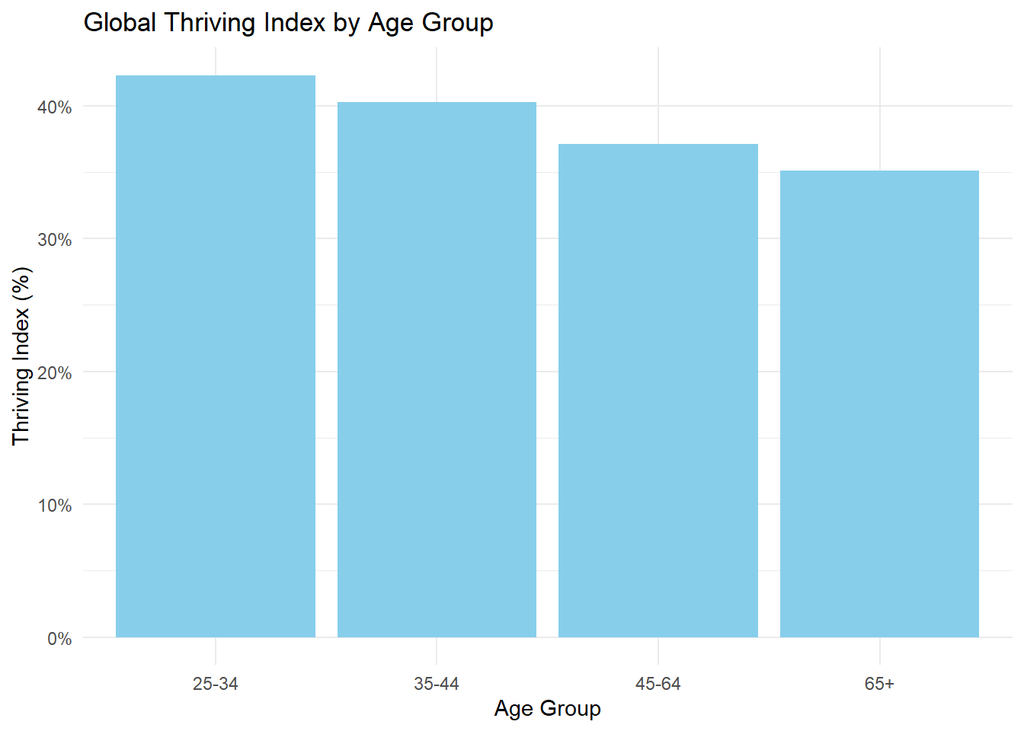

```r
# Plot for Age
plot_age_thriving <- global_wellbeing_global_clean %>%
  filter(Demographic_Category == "Age") %>%
  mutate(Demographic_Value = factor(Demographic_Value,
         levels = c("15-24", "25-34", "35-44", "45-64", "65+"))) %>%
  {
    if(nrow(.) == 0) {
      print("Still no data found for Demographic_Category == 'Age'. Check logic.")
    } else {
      ggplot(., aes(x = Demographic_Value, y = Thriving_Index_Pct)) +
        geom_bar(stat = "identity", fill = "skyblue") +
        scale_y_continuous(labels = scales::percent_format()) +
        labs(title = "Global Thriving Index by Age Group",
             x = "Age Group",
             y = "Thriving Index (%)") +
        theme_minimal()
    }
  }

if (exists("plot_age_thriving") && !is.null(plot_age_thriving)) {
  print(plot_age_thriving)
}
```

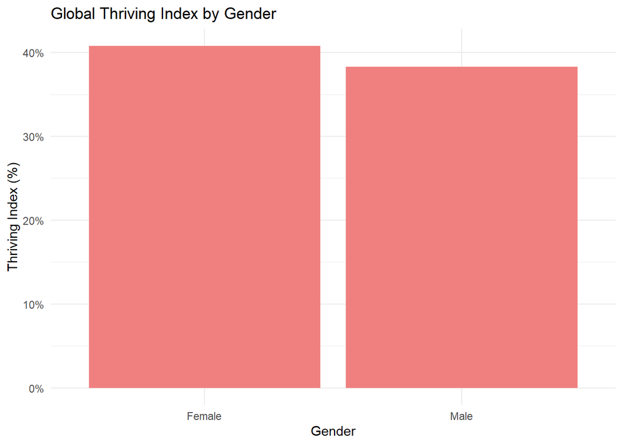

```r
# Plot for Gender
plot_gender_thriving <- global_wellbeing_global_clean %>%
  filter(Demographic_Category == "Gender") %>%
   {
    if(nrow(.) == 0) {
       print("No data found for Demographic_Category == 'Gender'. Check spelling/case.")
    } else {
      ggplot(., aes(x = Demographic_Value, y = Thriving_Index_Pct)) +
        geom_bar(stat = "identity", fill = "lightcoral") +
        scale_y_continuous(labels = scales::percent_format()) +
        labs(title = "Global Thriving Index by Gender",
             x = "Gender",
             y = "Thriving Index (%)") +
        theme_minimal()
    }
  }

if (exists("plot_gender_thriving") && !is.null(plot_gender_thriving)) {
  print(plot_gender_thriving)
}
```

```r
# DQ part: Find demographic group with highest/lowest thriving index
highest_thriving_group <- global_wellbeing_global_clean %>%
  arrange(desc(Thriving_Index_Pct)) %>%
  select(Demographic_Category, Demographic_Value, Thriving_Index_Pct) %>%
  head(1)

lowest_thriving_group <- global_wellbeing_global_clean %>%
   arrange(Thriving_Index_Pct) %>%
   select(Demographic_Category, Demographic_Value, Thriving_Index_Pct) %>%
   head(1)

print("Demographic group with highest Thriving Index:")
```

```
## [1] "Demographic group with highest Thriving Index:"
```

```r
print(highest_thriving_group)
```

```
## # A tibble: 1 × 3
##   Demographic_Category            Demographic_Value           Thriving_Index_Pct
##   <chr>                           <chr>                                    <dbl>
## 1 Feelings About Household Income Living comfortably on pres…               0.62
```

```r
print("Demographic group with lowest Thriving Index:")
```

```
## [1] "Demographic group with lowest Thriving Index:"
```

```r
print(lowest_thriving_group)
```

```
## # A tibble: 1 × 3
##   Demographic_Category            Demographic_Value           Thriving_Index_Pct
##   <chr>                           <chr>                                    <dbl>
## 1 Feelings About Household Income Finding it very difficult …              0.139
```

### Results

Assessment: Visualization clearly shows the global trend of thriving across age (generally declining) and gender (small female advantage). The query shows a strong association between perceived income security and thriving status.

## Task 2

### Background

Objective: Identify the strongest predictors of national happiness based on the World Happiness Report (Objective 1). This task specifically looks at the correlation between the WHR’s own ‘Social support’ factor and its overall ‘Score’.

Type: Data Visualization (Scatter Plot) & DQ (Correlation).

I use the cleaned WHR data (whr_2019_clean). A scatter plot visualizes the relationship between the social_support factor and the overall happiness score. Each point is a country. A linear regression line shows the trend, and the Pearson correlation coefficient quantifies the strength of the relationship. This tests if WHR’s measure of social support correlates with its overall happiness score.

### Code

```r
# Task 2: WHR Social Support vs WHR Happiness Score

# Calculate correlation
correlation_whr_support_score <- cor(whr_2019_clean$social_support,
                                     whr_2019_clean$score,
                                     use = "complete.obs")

print(paste("Correlation between WHR 'Social support' and WHR 'Score':",
            round(correlation_whr_support_score, 3)))
```

```
## [1] "Correlation between WHR 'Social support' and WHR 'Score': 0.777"
```

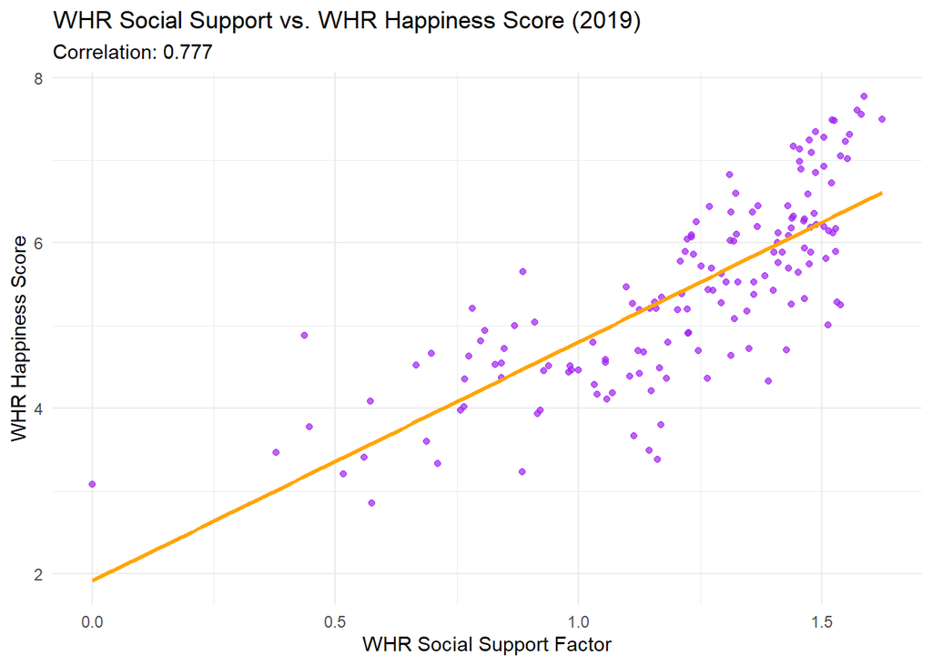

```r
# Create scatter plot
plot_whr_support_score <- ggplot(whr_2019_clean,
                                 aes(x = social_support, y = score)) +
  geom_point(alpha = 0.7, color = "purple") +
  geom_smooth(method = "lm", se = FALSE, color = "orange") +
  labs(title = "WHR Social Support vs. WHR Happiness Score (2019)",
       subtitle = paste("Correlation:", round(correlation_whr_support_score, 3)),
       x = "WHR Social Support Factor",
       y = "WHR Happiness Score") +
  theme_minimal()

print(plot_whr_support_score)
```

### Results

Assessment: There is a strong positive correlation (r = 0.777) between the World Happiness Report’s measure of social support and its overall happiness score. Countries with higher social support scores tend to have significantly higher happiness scores. This supports the idea that social support is a major component or predictor of national happiness as measured by the WHR.

## Task 3

### Background

Objective: Identify the strongest predictors of national happiness based on the World Happiness Report (Objective 1). This task specifically looks at the correlation between the WHR’s ‘GDP per capita’ factor and its overall ‘Score’.

Type: Data Visualization (Scatter Plot) & DQ (Correlation).

Explanation: Similar to Task 2, but using gdp_per_capita on the x-axis. I visualize and quantify the relationship between national economic output (as a proxy) and national happiness score using the WHR data.

### Code

```r
# Task 3: WHR GDP per capita vs WHR Happiness Score

# Calculate correlation
correlation_whr_gdp_score <- cor(whr_2019_clean$gdp_per_capita,
                                 whr_2019_clean$score,
                                 use = "complete.obs")

print(paste("Correlation between WHR 'GDP per capita' and WHR 'Score':",
            round(correlation_whr_gdp_score, 3)))
```

```
## [1] "Correlation between WHR 'GDP per capita' and WHR 'Score': 0.794"
```

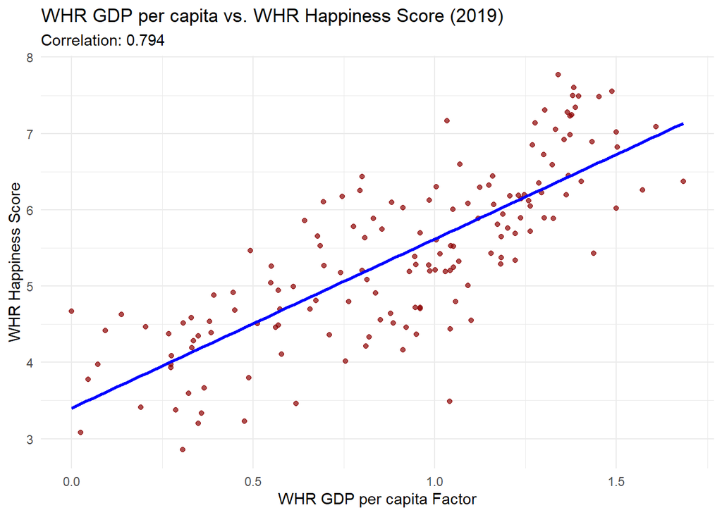

```r
# Create scatter plot
plot_whr_gdp_score <- ggplot(whr_2019_clean,
                             aes(x = gdp_per_capita, y = score)) +
  geom_point(alpha = 0.7, color = "darkred") +
  geom_smooth(method = "lm", se = FALSE, color = "blue") + # Use lm for linear trend
  labs(title = "WHR GDP per capita vs. WHR Happiness Score (2019)",
       subtitle = paste("Correlation:", round(correlation_whr_gdp_score, 3)),
       x = "WHR GDP per capita Factor",
       y = "WHR Happiness Score") +
  theme_minimal()

print(plot_whr_gdp_score)
```

### Results

Assessment: There is a very strong positive correlation (r = 0.794) between GDP per capita and the WHR Happiness Score. Countries with higher GDP per capita tend to have significantly higher happiness scores. Comparing this correlation (0.794) to the social support correlation (0.777) suggests that, based purely on these two linear correlations within the 2019 WHR data, GDP per capita has a slightly stronger linear association with the happiness score than social support does. The plot suggests the relationship might flatten slightly at the very highest GDP levels, hinting at potential non-linearity (diminishing returns), but the overall linear trend is dominant.

## Task 4

### Background

Objective: Examine relationships between well-being indicators and happiness across different datasets (related to Objective 2). Specifically, correlate the validated WHR ‘Score’ with the GWBI ‘Thriving Index’ proxy.

Type: Data Visualization (Scatter Plot) & DQ (Correlation).

I use the country_data_joined_complete dataset which contains matched data from both sources (using the Male proxy for GWBI). A scatter plot visualizes the relationship between the GWBI Thriving_Index_Pct (our proxy for happiness/well-being in GWBI) and the WHR score. The correlation coefficient quantifies how well these two different measures of national well-being align for the countries where data is available in both sets.

### Code

```r
# Task 4: Compare WHR Score vs GWBI Thriving Index (Joined Data)

# Calculate correlation using the joined data (complete cases only)
correlation_whr_gwbi <- cor(country_data_joined_complete$Thriving_Index_Pct,
                            country_data_joined_complete$score,
                            use = "complete.obs") # Should be complete already

print(paste("Correlation between GWBI 'Thriving Index % (Male Proxy)' and WHR 'Score':",
            round(correlation_whr_gwbi, 3)))
```

```
## [1] "Correlation between GWBI 'Thriving Index % (Male Proxy)' and WHR 'Score': 0.894"
```

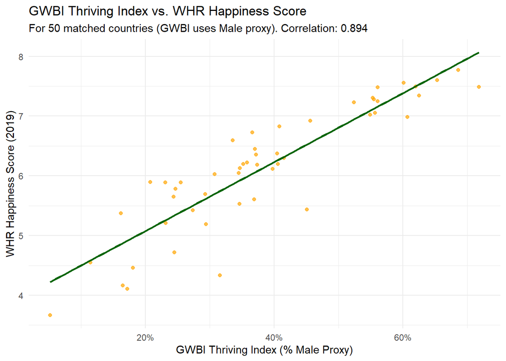

```r
# Create scatter plot
plot_whr_gwbi <- ggplot(country_data_joined_complete,
                        aes(x = Thriving_Index_Pct, y = score)) +
  geom_point(alpha = 0.7, color = "orange") +
  geom_smooth(method = "lm", se = FALSE, color = "darkgreen") +
  scale_x_continuous(labels = scales::percent_format()) +
  labs(title = "GWBI Thriving Index vs. WHR Happiness Score",
       subtitle = paste("For", nrow(country_data_joined_complete), "matched countries (GWBI uses Male proxy). Correlation:",
                        round(correlation_whr_gwbi, 3)),
       x = "GWBI Thriving Index (% Male Proxy)",
       y = "WHR Happiness Score (2019)") +
  theme_minimal()

print(plot_whr_gwbi)
```

### Results

Assessment: There is a very strong positive correlation (r = 0.894) between the GWBI Thriving Index (using the Male proxy) and the WHR Happiness Score for the matched countries. This suggests that the Thriving Index measure from the Gallup Wellbeing Initiative, even when proxied by a single demographic, aligns well with the more comprehensive World Happiness Report score at the national level. Countries scoring high on one measure tend to score high on the other.

## Task 5

### Background

Objective: Examine demographic variations in well-being indicators (Objective 4), focusing specifically on how the perception of household income relates to both Thriving and Struggling indices globally.

Type: Data Visualization (Line Plot).

Explanation: I use the global_wellbeing_global_clean data, filtering for the Demographic_Category == “Feelings About Household Income”. I pivot the data longer to have ‘Index_Type’ (Thriving/Struggling) and ‘Percentage’ columns. A line plot created with ggplot2 shows how the percentages for Thriving and Struggling change across the different income feeling categories, allowing direct comparison.

### Code

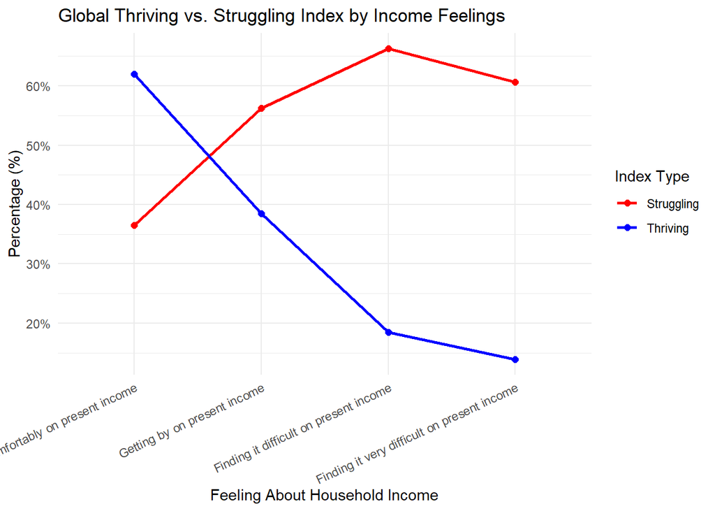

```r
# Task 5: Plot Thriving and Struggling Indices by Household Income Feeling (Global)

# Prepare data for plotting
income_feeling_data <- global_wellbeing_global_clean %>%
  filter(Demographic_Category == "Feelings About Household Income") %>%
  select(Demographic_Value, Thriving_Index_Pct, Struggling_Index_Pct) %>%
  pivot_longer(cols = c(Thriving_Index_Pct, Struggling_Index_Pct),
               names_to = "Index_Type",
               values_to = "Percentage") %>%
  mutate(Index_Type = ifelse(Index_Type == "Thriving_Index_Pct", "Thriving", "Struggling")) %>%
  mutate(Demographic_Value = factor(Demographic_Value,
          levels = c("Living comfortably on present income",
                     "Getting by on present income",
                     "Finding it difficult on present income",
                     "Finding it very difficult on present income")))


# Create the plot
plot_income_wellbeing <- ggplot(income_feeling_data,
                              aes(x = Demographic_Value, y = Percentage,
                                  group = Index_Type, color = Index_Type)) +
  geom_line(linewidth = 1) +
  geom_point(size = 2) +
  scale_y_continuous(labels = scales::percent_format()) +
  scale_color_manual(values = c("Struggling" = "red", "Thriving" = "blue")) +
  labs(title = "Global Thriving vs. Struggling Index by Income Feelings",
       x = "Feeling About Household Income",
       y = "Percentage (%)",
       color = "Index Type") +
  theme_minimal() +
  theme(axis.text.x = element_text(angle = 25, hjust = 1))

print(plot_income_wellbeing)
```

### Results Assessment: The visualization demonstrates an inverse relationship between perceived income adequacy and the balance between thriving and struggling globally. As financial difficulty increases, the population shifts from thriving towards struggling. This reinforces findings from Task 1 and highlights perceived economic security as a dominant factor in these specific well-being indices.

# Comments and Remarks on Objectives

## Objective Status:

Obj 1 (Identify strongest WHR predictors): Partially addressed by Tasks 2 & 3, which showed both GDP per capita (r=0.794) and Social Support (r=0.777) are very strong correlates of the WHR Score. Further analysis comparing all WHR factors is needed to definitively identify the strongest.

Obj 2 (Examine GWBI relationships): Partially addressed. Task 4 showed a strong correlation between the GWBI Thriving Index proxy and the WHR Score, suggesting the GWBI indicators capture related aspects of well-being. Tasks focusing on GWBI indicators like social support (‘Count on Help’) and health vs. Thriving were performed in the previous draft (Tasks 2 & 3 there) using the aggregated country data and showed expected correlations, but were replaced here by WHR-focused tasks to better align with Objective 1. These could be added back in later project stages.

Obj 3 (Compare social support vs health): Addressed implicitly by comparing correlations in the previous draft’s Tasks 2 & 3 (using GWBI data), which suggested similar magnitudes of correlation. Requires further dedicated analysis, possibly using regression, once all data is integrated.

Obj 5 (Build predictive model): Not addressed in this assignment, requires WHR data integration and machine learning techniques for later.

## Rationale for Change/Focus

The inclusion of the WHR dataset allowed for direct investigation of Objective 1, leading to the replacement of some initially planned GWBI-only tasks (like comparing GWBI social support vs health correlation directly) with WHR-focused analyses (Tasks 2 & 3 here) and a cross-dataset comparison (Task 4 here). Tasks 1 & 5 looked at GWBI demographic exploration (Objective 4). The predictive modeling (Objective 5) is unfulfilled as it is beyond the scope of this assignment but will be addressed by a future assignment. The use of the GWBI Thriving Index as a proxy seems validated by Task 4. The limitation of using a single demographic (‘Male’) as a proxy for national GWBI aggregates remains for Task 4 (and would apply if the original Tasks 2 & 3 were kept).